# Clase 17. VAR(p) — IRF Recursivo (SVAR)

Series de Tiempo | Semestre 2027-I | FC-UNAM

Benjamin Oliva & Luis Gerardo Ruiz González

October 2026

## ¿Qué aprenderemos hoy?

Estimamos un VAR estructural recursivo (SVAR con restricciones de corto plazo) para medir cómo responden el consumo y la inversión en México a un choque de **incertidumbre de política comercial de Estados Unidos**. Antes de estimar, desestacionalizamos las series con X-13. El esquema recursivo (Cholesky) es el más sencillo de identificar; el jueves veremos restricciones de largo plazo (Blanchard y Quah, 1989) y de signo (Uhlig, 2005).

Al terminar esta clase deberás poder:

1. Preprocesar series con ajuste estacional X-13 y transformarlas en tasas de crecimiento anual antes de estimar un VAR
2. Explicar qué supuesto económico impone el **orden** de las variables en una identificación recursiva
3. Estimar e interpretar IRF estructurales con `vars::irf(ortho = TRUE)` y con `svars::id.chol()`, y explicar por qué ambas dan el mismo punto y bandas distintas

**Datos:** `VAR_Recursivo.xlsx` (mensual, ene-1999 a feb-2025, 314 observaciones)

## 1. Del VAR reducido al VAR estructural

El VAR en forma reducida que estimamos en las clases 15 y 16 es

$$Y_t = c + A_1 Y_{t-1} + \dots + A_p Y_{t-p} + u_t, \qquad E[u_t
u_t'] = \Sigma_u .$$

Los errores $u_t$ están correlacionados entre ecuaciones, así que un “choque en $u_{2t}$” no tiene interpretación económica: siempre viene acompañado de movimientos en los otros errores. Suponemos que los errores reducidos son combinaciones lineales de **choques estructurales** $\varepsilon_t$ no correlacionados:

$$u_t = B\,\varepsilon_t, \qquad E[\varepsilon_t \varepsilon_t'] = I
\quad\Longrightarrow\quad B B' = \Sigma_u .$$

$\Sigma_u$ es simétrica y aporta $n(n+1)/2$ ecuaciones, pero $B$ tiene $n^2$ incógnitas: faltan $n(n-1)/2$ restricciones. La identificación **recursiva** las obtiene haciendo $B$ triangular inferior, es decir, $B = \text{chol}(\Sigma_u)$. Así:

- la variable 1 sólo reacciona en el mismo mes a su propio choque;
- la variable 2 reacciona en el mismo mes a los choques 1 y 2;
- … y la última variable reacciona en el mismo mes a todos los choques.

Por eso **el orden de las variables es el supuesto de identificación**. A partir del mes siguiente todas las variables pueden responder a todos los choques a través de los rezagos. La IRF estructural a $h$ periodos es $\Theta_h = \Psi_h B$, donde $\Psi_h$ son los coeficientes de la representación MA($\infty$) del VAR (Clase 16).

## 2. Paquetes y datos

```r
# En un .Rmd el directorio de trabajo es la carpeta del propio archivo,
# de modo que las rutas relativas funcionan sin setwd().
Sys.setlocale("LC_TIME", "es_ES.UTF-8")
```

```
## [1] "es_ES.UTF-8"
```

```r
if (!require(pacman)) install.packages("pacman")
```

```r
library(pacman)
p_load("readxl", "seasonal", "ggplot2", "dplyr", "vars", "svars", "lubridate",
       "zoo", "tseries", "scales", "stats", "tidyr", "ggthemes", "knitr")

data <- read_excel("VAR_Recursivo.xlsx")
head(data)
```

```
## # A tibble: 6 × 9
##   fecha                cons   inv   inc  shad   fix  igae cetes inv.p
##   <dttm>              <dbl> <dbl> <dbl> <dbl> <dbl> <dbl> <dbl> <dbl>
## 1 1999-01-01 00:00:00  61.6  65.4  95.7  4.76 10.1   69.5  32.1  68.4
## 2 1999-02-01 00:00:00  60.0  67.1  78.1  4.85  9.99  69.5  28.8  69.9
## 3 1999-03-01 00:00:00  65.4  69.2  61.9  4.73  9.73  69.7  23.5  62.5
## 4 1999-04-01 00:00:00  64.5  62.7  58.8  4.74  9.42  69.8  20.3  55.3
## 5 1999-05-01 00:00:00  65.9  63.5  72.2  4.74  9.41  70.1  19.9  52.8
## 6 1999-06-01 00:00:00  65.8  63.1  71.7  4.93  9.51  69.8  21.1  63.9
```

Las variables de la hoja `Hoja1` son:

| Variable | Descripción | Fuente | Unidad | Transformación |
| --- | --- | --- | --- | --- |
| `fecha` | Mes de la observación | — | ene-1999 a feb-2025 | — |
| `shad` | Tasa sombra de fondos federales de Wu y Xia (coincide con la tasa efectiva de la Fed fuera del límite inferior cero; es negativa en 2009-2015) | Reserva Federal de Atlanta | % anual | Nivel |
| `inc` | Índice de incertidumbre de política comercial de EE.UU. (componente “9. Trade policy” del EPU categórico) | Baker, Bloom y Davis, [policyuncertainty.com](https://www.policyuncertainty.com/categorical_epu.html) | Índice | Nivel |
| `fix` | Tipo de cambio FIX | Banxico | Pesos por dólar | Crecimiento anual |
| `igae` | Indicador Global de la Actividad Económica, con ajuste estacional | INEGI, base 2018 = 100 | Índice | Crecimiento anual |
| `cons` | Indicador mensual del consumo privado en el mercado interior | INEGI, base 2018 = 100 | Índice | X-13 y crecimiento anual |
| `inv` | Indicador mensual de la inversión fija bruta total | INEGI, base 2018 = 100 | Índice | X-13 y crecimiento anual |
| `inv.p` | Indicador mensual de la inversión fija bruta pública | INEGI, base 2018 = 100 | Índice | X-13 y crecimiento anual |
| `cetes` | Tasa de CETES a 28 días | Banxico | % anual | Nivel |

`cons`, `inv` e `inv.p` vienen **sin** ajuste estacional; `igae` ya viene desestacionalizado de origen y `fix`, `shad`, `inc` y `cetes` no tienen un patrón estacional relevante.

## 3. Ajuste estacional con X-13

`seas()` necesita saber en qué mes empieza la serie: con esa información construye los regresores de días hábiles y de Semana Santa y fecha los valores atípicos. Por eso tomamos el inicio de la propia columna `fecha` en lugar de escribirlo a mano.

```r
inicio <- c(year(min(data$fecha)), month(min(data$fecha)))
inicio
```

```
## [1] 1999    1
```

```r
vars_sa <- c("cons", "inv", "inv.p")

for (v in vars_sa) {
  ts_temp <- ts(
    data[[v]],
    start     = inicio,
    frequency = 12
  )
  data_sa <- seas(ts_temp)
  data[[paste0(v, "_sa")]] <- as.numeric(final(data_sa))
}

# Modelo elegido por X-13 para el consumo: regresores, atípicos y ARIMA estacional
summary(seas(ts(data$cons, start = inicio, frequency = 12)))
```

```
##
## Call:
## seas(x = ts(data$cons, start = inicio, frequency = 12))
##
## Coefficients:
##                    Estimate Std. Error z value Pr(>|z|)
## Leap Year           1.02468    0.27883   3.675 0.000238 ***
## Mon                 0.30947    0.09241   3.349 0.000811 ***
## Tue                 0.30056    0.09092   3.306 0.000947 ***
## Wed                 0.05657    0.09096   0.622 0.534004
## Thu                 0.35069    0.08928   3.928 8.57e-05 ***
## Fri                 0.23694    0.08918   2.657 0.007888 **
## Sat                -0.26374    0.08909  -2.960 0.003072 **
## Easter[1]          -2.07145    0.17977 -11.523  < 2e-16 ***
## LS2008.Dec         -4.30544    0.78040  -5.517 3.45e-08 ***
## AO2020.Mar         -6.26619    0.85990  -7.287 3.17e-13 ***
## LS2020.Apr        -23.86638    0.95861 -24.897  < 2e-16 ***
## AO2020.Jun         -4.10113    0.85450  -4.799 1.59e-06 ***
## LS2020.Jun          9.31169    0.95035   9.798  < 2e-16 ***
## LS2020.Sep          4.50658    0.78855   5.715 1.10e-08 ***
## MA-Nonseasonal-01   0.36980    0.05326   6.944 3.82e-12 ***
## MA-Seasonal-12      0.49640    0.05269   9.422  < 2e-16 ***
## ---
## Signif. codes:  0 '***' 0.001 '**' 0.01 '*' 0.05 '.' 0.1 ' ' 1
##
## SEATS adj.  ARIMA: (0 1 1)(0 1 1)  Obs.: 314  Transform: none
## AICc: 871.3, BIC: 932.1  QS (no seasonality in final):    0
## Box-Ljung (no autocorr.): 22.96   Shapiro (normality): 0.9907 *
```

Fíjate en la lista de atípicos: X-13 encuentra los cambios de nivel de dic-2008 (crisis financiera) y abr-2020 (confinamiento por COVID-19), y el regresor de Semana Santa (`Easter`) es muy significativo. Si se declara mal el mes de inicio, los mismos choques aparecen con fechas imposibles (por ejemplo, “2030”) y el efecto de Semana Santa se asigna a meses equivocados.

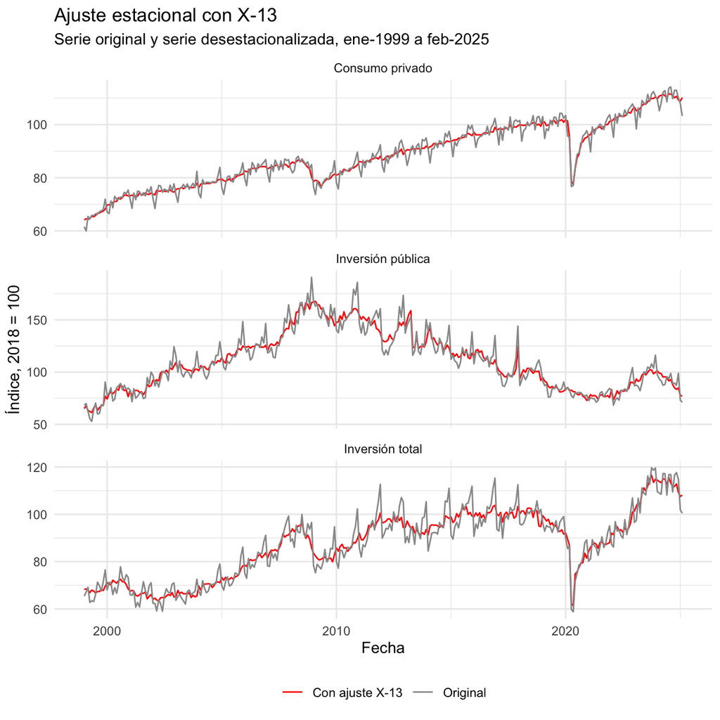

```r
data %>%
  dplyr::select(fecha, cons, cons_sa, inv, inv_sa, inv.p, inv.p_sa) %>%
  pivot_longer(-fecha) %>%
  mutate(
    variable = case_when(
      grepl("^cons", name)  ~ "Consumo privado",
      grepl("^inv\\.p", name) ~ "Inversión pública",
      TRUE                  ~ "Inversión total"),
    serie = ifelse(grepl("_sa$", name), "Con ajuste X-13", "Original")) %>%
  ggplot(aes(x = fecha, y = value, colour = serie)) +
  geom_line() +
  facet_wrap(~ variable, ncol = 1, scales = "free_y") +
  scale_colour_manual(values = c("Original" = "gray60", "Con ajuste X-13" = "red")) +
  labs(title = "Ajuste estacional con X-13",
       subtitle = "Serie original y serie desestacionalizada, ene-1999 a feb-2025",
       x = "Fecha", y = "Índice, 2018 = 100", colour = NULL) +
  theme_minimal() +
  theme(legend.position = "bottom")
```

```r
data <- data %>%
  dplyr::select(fecha, cons_sa, inv_sa, inv.p_sa, inc, shad, fix, igae, cetes)
```

## 4. Tasas de crecimiento anual

Las variables en índice o en pesos por dólar tienen tendencia, así que las expresamos como crecimiento anual en logaritmos, $\ln X_t - \ln X_{t-12}$. Una respuesta de $-0.005$ en estas variables significa **medio punto porcentual menos** de crecimiento anual. Las tasas (`shad`, `cetes`) y el índice de incertidumbre (`inc`) se quedan en niveles. Perdemos los primeros 12 meses: la muestra del VAR empieza en ene-2000.

```r
data.ln <- function(data, vars) {
  for (v in vars) {
    data[[v]] <- log(data[[v]]) - log(dplyr::lag(data[[v]], 12))
  }
  return(data)
}

vars_ln <- c("cons_sa", "inv_sa", "inv.p_sa", "fix", "igae")

data1 <- data.ln(data, vars_ln) %>%
  drop_na()

range(data1$fecha)
```

```
## [1] "2000-01-01 UTC" "2025-02-01 UTC"
```

```r
nrow(data1)
```

```
## [1] 302
```

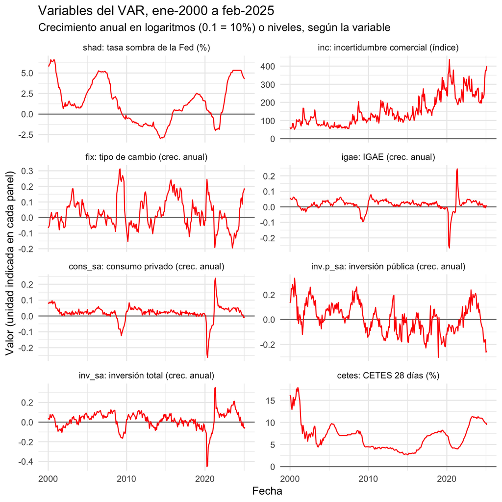

```r
etiquetas <- c(
  shad     = "shad: tasa sombra de la Fed (%)",
  inc      = "inc: incertidumbre comercial (índice)",
  fix      = "fix: tipo de cambio (crec. anual)",
  igae     = "igae: IGAE (crec. anual)",
  cons_sa  = "cons_sa: consumo privado (crec. anual)",
  inv.p_sa = "inv.p_sa: inversión pública (crec. anual)",
  inv_sa   = "inv_sa: inversión total (crec. anual)",
  cetes    = "cetes: CETES 28 días (%)")

data1 %>%
  pivot_longer(-fecha) %>%
  mutate(name = factor(etiquetas[name], levels = etiquetas)) %>%
  ggplot(aes(x = fecha, y = value)) +
  geom_hline(yintercept = 0, colour = "gray50") +
  geom_line(colour = "red") +
  facet_wrap(~ name, ncol = 2, scales = "free_y") +
  labs(title = "Variables del VAR, ene-2000 a feb-2025",
       subtitle = "Crecimiento anual en logaritmos (0.1 = 10%) o niveles, según la variable",
       x = "Fecha", y = "Valor (unidad indicada en cada panel)") +
  theme_minimal()
```

## 5. Pruebas de raíz unitaria

Usamos la prueba ADF con constante (`type = "drift"`) y elegimos los rezagos por AIC hasta 12 meses (Clase 13). Rechazamos la raíz unitaria al 5% si el estadístico $\tau$ es menor que el valor crítico.

```r
vars_adf <- c("cons_sa", "inv_sa", "inv.p_sa", "inc", "shad", "fix", "igae", "cetes")

tabla_adf <- do.call(rbind, lapply(vars_adf, function(v) {
  prueba <- ur.df(data1[[v]], type = "drift", lags = 12, selectlags = "AIC")
  data.frame(
    variable  = v,
    tau       = round(prueba@teststat[1, "tau2"], 2),
    vc_5      = prueba@cval["tau2", "5pct"],
    rechaza_5 = prueba@teststat[1, "tau2"] < prueba@cval["tau2", "5pct"])
}))

kable(tabla_adf, col.names = c("Variable", "τ", "Valor crítico 5%", "¿Rechaza raíz unitaria?"))
```

| Variable | τ | Valor crítico 5% | ¿Rechaza raíz unitaria? |
| --- | --- | --- | --- |
| cons_sa | -3.42 | -2.87 | TRUE |
| inv_sa | -3.33 | -2.87 | TRUE |
| inv.p_sa | -2.88 | -2.87 | TRUE |
| inc | -0.89 | -2.87 | FALSE |
| shad | -2.63 | -2.87 | FALSE |
| fix | -3.06 | -2.87 | TRUE |
| igae | -3.50 | -2.87 | TRUE |
| cetes | -4.70 | -2.87 | TRUE |

Las tasas de crecimiento y CETES son estacionarias. `inv.p_sa` queda en la frontera, la tasa sombra no rechaza por poco y el índice de incertidumbre **no rechaza**: su nivel sube de forma persistente desde 2016. En la literatura de incertidumbre (Caldara et al., 2020) es habitual estimar el VAR con estos índices en niveles; las estimaciones por MCO siguen siendo consistentes, pero la inferencia es menos confiable. Lo retomamos en el Ejercicio 3.

## 6. Orden recursivo, rezagos y estimación

Estimamos dos VAR, uno para el consumo y otro para la inversión. El orden va **de lo más exógeno a lo más endógeno** para la economía mexicana en el mismo mes:

1. `shad`: la Fed no reacciona en el mes a lo que pasa en México.
2. `inc`: la incertidumbre comercial de EE.UU. puede responder a la Fed, pero no a variables mexicanas.
3. `fix`: el tipo de cambio es un precio financiero que absorbe de inmediato los choques externos.
4. `igae`: la actividad agregada.
5. `cons_sa` (o `inv.p_sa` y luego `inv_sa`): el componente del gasto que nos interesa. La inversión pública va antes que la total porque se decide con el presupuesto y no responde en el mes a la inversión privada.
6. `cetes`: Banxico observa todo lo anterior y reacciona en el mes; sus decisiones afectan la actividad sólo con rezago.

```r
vars_cons <- c("shad", "inc", "fix", "igae", "cons_sa", "cetes")
vars_inv  <- c("shad", "inc", "fix", "igae", "inv.p_sa", "inv_sa", "cetes")

# CONSUMO:
VARselect(data1[, vars_cons], lag.max = 6, type = "const")$selection
```

```
## AIC(n)  HQ(n)  SC(n) FPE(n)
##      3      2      2      3
```

```r
# INVERSIÓN:
VARselect(data1[, vars_inv], lag.max = 6, type = "const")$selection
```

```
## AIC(n)  HQ(n)  SC(n) FPE(n)
##      3      2      1      3
```

AIC y FPE sugieren 3 rezagos y los criterios más parsimoniosos (HQ, SC) entre 1 y 2. Con 6 y 7 variables cada rezago añade 36 o 49 coeficientes, así que tomamos el criterio de Schwarz: $p = 2$ para el consumo y $p = 1$ para la inversión.

```r
# CONSUMO:
c.r.var <- vars::VAR(
  data1[, vars_cons],
  p      = 2,
  type   = "const")

# INVERSIÓN:
i.r.var <- vars::VAR(
  data1[, vars_inv],
  p      = 1,
  type   = "const")

# Estabilidad: todas las raíces del polinomio característico deben ser menores que 1
max(roots(c.r.var))
```

```
## [1] 0.9847657
```

```r
max(roots(i.r.var))
```

```
## [1] 0.987497
```

```r
# Autocorrelación de los residuales (Portmanteau, 24 rezagos)
serial.test(c.r.var, lags.pt = 24, type = "PT.adjusted")$serial
```

```
##
##  Portmanteau Test (adjusted)
##
## data:  Residuals of VAR object c.r.var
## Chi-squared = 1118.3, df = 792, p-value = 1.442e-13
```

```r
serial.test(i.r.var, lags.pt = 24, type = "PT.adjusted")$serial
```

```
##
##  Portmanteau Test (adjusted)
##
## data:  Residuals of VAR object i.r.var
## Chi-squared = 1916.2, df = 1127, p-value < 2.2e-16
```

Ambos VAR son estables, aunque con raíces cercanas a 1 (las respuestas serán persistentes). La prueba Portmanteau **rechaza** la ausencia de autocorrelación: con tan pocos rezagos los residuales todavía tienen estructura. Lo dejamos así para que el ejemplo sea fácil de seguir, pero conviene revisar si las IRF cambian con $p = 3$ (Ejercicio 3).

## 7. Opción A: IRF ortogonalizadas con `vars`

`irf(..., ortho = TRUE)` calcula $\Theta_h = \Psi_h B$ con $B = \text{chol}(\Sigma_u)$ en el orden en que aparecen las columnas. El choque es de **una desviación estándar** del choque estructural de incertidumbre; las bandas al 90% salen de un bootstrap de residuales con 1,000 réplicas.

```r
# Tamaño del choque: elemento (inc, inc) de B, en puntos del índice
B.c <- t(chol(summary(c.r.var)$covres))
round(B.c, 4)
```

```
##            shad     inc     fix   igae cons_sa  cetes
## shad     0.2137  0.0000  0.0000 0.0000  0.0000 0.0000
## inc     -3.9338 29.2496  0.0000 0.0000  0.0000 0.0000
## fix     -0.0007  0.0068  0.0351 0.0000  0.0000 0.0000
## igae     0.0009 -0.0010 -0.0032 0.0188  0.0000 0.0000
## cons_sa  0.0006 -0.0015 -0.0049 0.0161  0.0096 0.0000
## cetes   -0.0013  0.0747  0.0280 0.0462 -0.0080 0.4774
```

```r
B.c["inc", "inc"]
```

```
## [1] 29.24961
```

Un choque de una desviación estándar equivale a unos 29 puntos del índice de incertidumbre; para dimensionarlo, el índice promedió 195 en 2018 y 388 en ene-feb 2025.

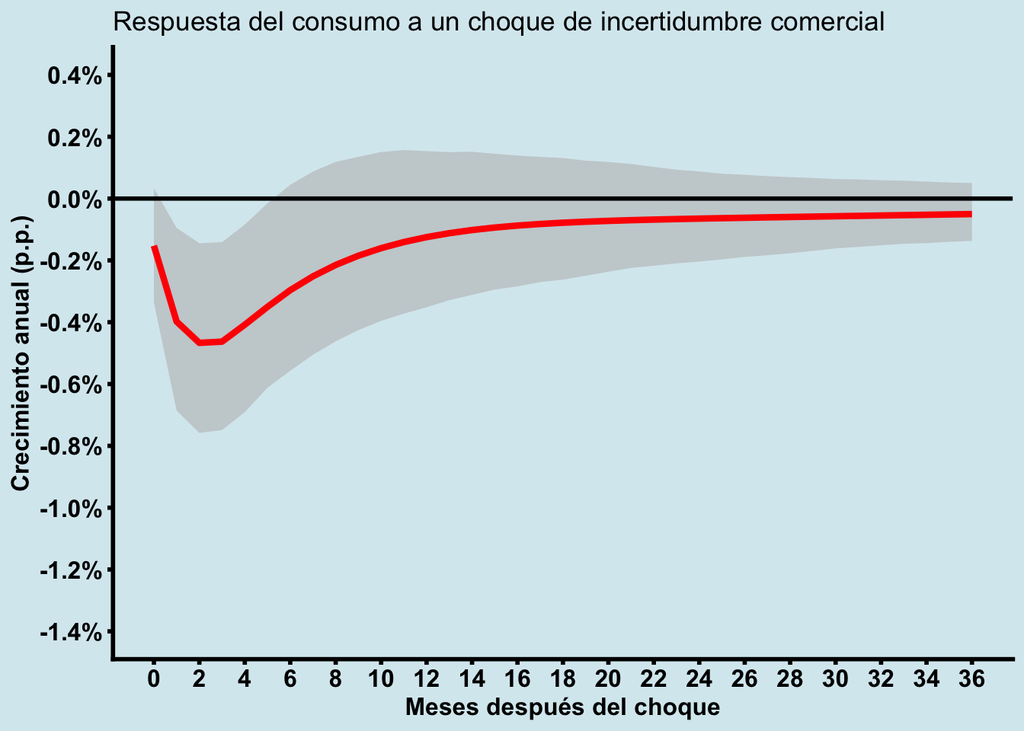

```r
# Convierte un objeto de vars::irf en data frame y lo grafica.
# coord_cartesian() acota la vista sin eliminar datos: con limits= en la escala,
# ggplot descarta los tramos de la banda que se salen del rango.
graficar_irf <- function(obj, impulso, titulo) {
  df <- data.frame(
    resp = obj$irf[[impulso]][, 1],
    low  = obj$Lower[[impulso]][, 1],
    upp  = obj$Upper[[impulso]][, 1],
    time = 0:(nrow(obj$irf[[impulso]]) - 1))

  ggplot(df, aes(x = time)) +
    geom_ribbon(aes(ymin = low, ymax = upp), fill = "gray", alpha = 0.6) +
    geom_hline(aes(yintercept = 0), colour = "black", linewidth = 1) +
    geom_line(aes(y = resp), colour = "red", linetype = "solid", linewidth = 1.5) +
    scale_y_continuous(breaks = seq(-.014, .004, by = .002),
                       labels = label_percent(accuracy = .1)) +
    scale_x_continuous(breaks = seq(from = 0, to = 36, by = 2)) +
    coord_cartesian(ylim = c(-.014, .004)) +
    labs(title = titulo, x = "Meses después del choque",
         y = "Crecimiento anual (p.p.)") +
    theme_classic() +
    theme(
      axis.text = element_text(size = 12, colour = "black", face = "bold"),
      axis.title = element_text(size = 12, face = "bold"),
      panel.background = element_rect(fill = "#d8eaf0", colour = NA),
      plot.background = element_rect(fill = "#d8eaf0", colour = NA),
      axis.line = element_line(linewidth = 1, colour = "black"),
      axis.ticks = element_line(linewidth = 1, colour = "black"))
}

set.seed(2027)

# CONSUMO:
c.irf <- vars::irf(c.r.var, impulse = "inc", response = "cons_sa",
                   n.ahead = 36, ortho = TRUE, boot = TRUE, ci = 0.90,
                   runs = 1000)
irf.c <- graficar_irf(c.irf, "inc", "Respuesta del consumo a un choque de incertidumbre comercial")
irf.c
```

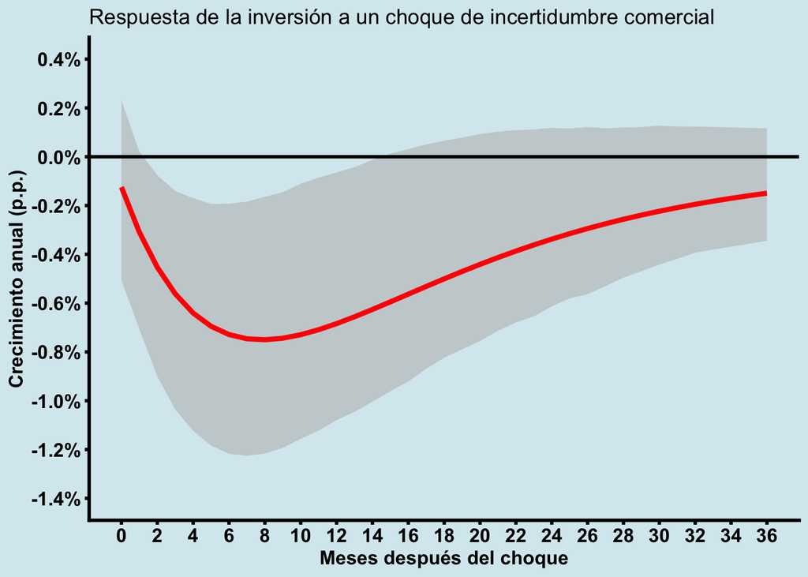

```r
# INVERSIÓN:
i.irf <- vars::irf(i.r.var, impulse = "inc", response = "inv_sa",
                   n.ahead = 36, ortho = TRUE, boot = TRUE, ci = 0.90,
                   runs = 1000)
irf.i <- graficar_irf(i.irf, "inc", "Respuesta de la inversión a un choque de incertidumbre comercial")
irf.i
```

```r
# Respuestas puntuales en meses seleccionados (en puntos porcentuales)
meses <- c(0, 3, 6, 12, 24, 36)
data.frame(
  mes       = meses,
  consumo   = round(100 * c.irf$irf$inc[meses + 1, 1], 2),
  inversion = round(100 * i.irf$irf$inc[meses + 1, 1], 2))
```

```
##   mes consumo inversion
## 1   0   -0.15     -0.12
## 2   3   -0.46     -0.56
## 3   6   -0.30     -0.73
## 4  12   -0.12     -0.68
## 5  24   -0.06     -0.34
## 6  36   -0.05     -0.15
```

**Lectura.** Tras un aumento de la incertidumbre comercial de EE.UU., el crecimiento anual del consumo cae alrededor de medio punto porcentual en los primeros meses y se recupera hacia el año. La inversión cae más y de forma más persistente (el máximo llega entre 6 y 12 meses): es el canal de “esperar y ver” de las decisiones irreversibles. Como trabajamos con tasas anuales, una caída sostenida de la tasa implica una pérdida de **nivel** acumulada.

## 8. Opción B: identificación con `svars`

`svars::id.chol()` toma el VAR reducido y calcula la misma $B = \text{chol}(\Sigma_u)$. La diferencia con la Opción A está en la **inferencia**: `wild.boot()` usa un bootstrap salvaje (multiplica los residuales por variables aleatorias de Rademacher), que es robusto a heterocedasticidad condicional, frecuente en datos financieros y en periodos como 2008-2009 y 2020.

```r
# CONSUMO:
c.svar <- id.chol(c.r.var)
summary(c.svar)
```

```
##
## Identification Results
## ----------------------
##
## Method: Cholesky
## Sample size: 300
##
## Estimated B Matrix (unique decomposition of the covariance matrix):
##                  [,1]          [,2]         [,3]       [,4]         [,5]
## shad     0.2137372031  0.0000000000  0.000000000 0.00000000  0.000000000
## inc     -3.9337832004 29.2496103372  0.000000000 0.00000000  0.000000000
## fix     -0.0007056730  0.0067781674  0.035149814 0.00000000  0.000000000
## igae     0.0009016594 -0.0009786146 -0.003166838 0.01880636  0.000000000
## cons_sa  0.0006397339 -0.0015256388 -0.004876867 0.01610551  0.009610008
## cetes   -0.0013420255  0.0746728609  0.027988472 0.04618493 -0.008030476
##              [,6]
## shad    0.0000000
## inc     0.0000000
## fix     0.0000000
## igae    0.0000000
## cons_sa 0.0000000
## cetes   0.4774184
```

```r
# INVERSIÓN:
i.svar <- id.chol(i.r.var)
summary(i.svar)
```

```
##
## Identification Results
## ----------------------
##
## Method: Cholesky
## Sample size: 301
##
## Estimated B Matrix (unique decomposition of the covariance matrix):
##                  [,1]         [,2]         [,3]         [,4]        [,5]
## shad      0.230762299  0.000000000  0.000000000  0.000000000 0.000000000
## inc      -2.516611861 30.070428795  0.000000000  0.000000000 0.000000000
## fix      -0.001148168  0.007576142  0.036876572  0.000000000 0.000000000
## igae      0.001180195 -0.002242387 -0.005191652  0.020702062 0.000000000
## inv.p_sa -0.001321630  0.002351830  0.001666277 -0.001230474 0.061144886
## inv_sa    0.002702981 -0.001246333 -0.010448892  0.030318127 0.004985574
## cetes     0.040033659  0.088356712  0.018831293  0.060463212 0.072948125
##                 [,6]      [,7]
## shad      0.00000000 0.0000000
## inc       0.00000000 0.0000000
## fix       0.00000000 0.0000000
## igae      0.00000000 0.0000000
## inv.p_sa  0.00000000 0.0000000
## inv_sa    0.02568613 0.0000000
## cetes    -0.03221201 0.4772914
```

```r
# Verificación: la matriz de impacto de svars es la misma que en la Opción A
all.equal(unname(c.svar$B), unname(B.c), tolerance = 1e-6)
```

```
## [1] TRUE
```

La identificación es idéntica (`TRUE`), así que la respuesta puntual coincide con la Opción A; sólo cambian las bandas.

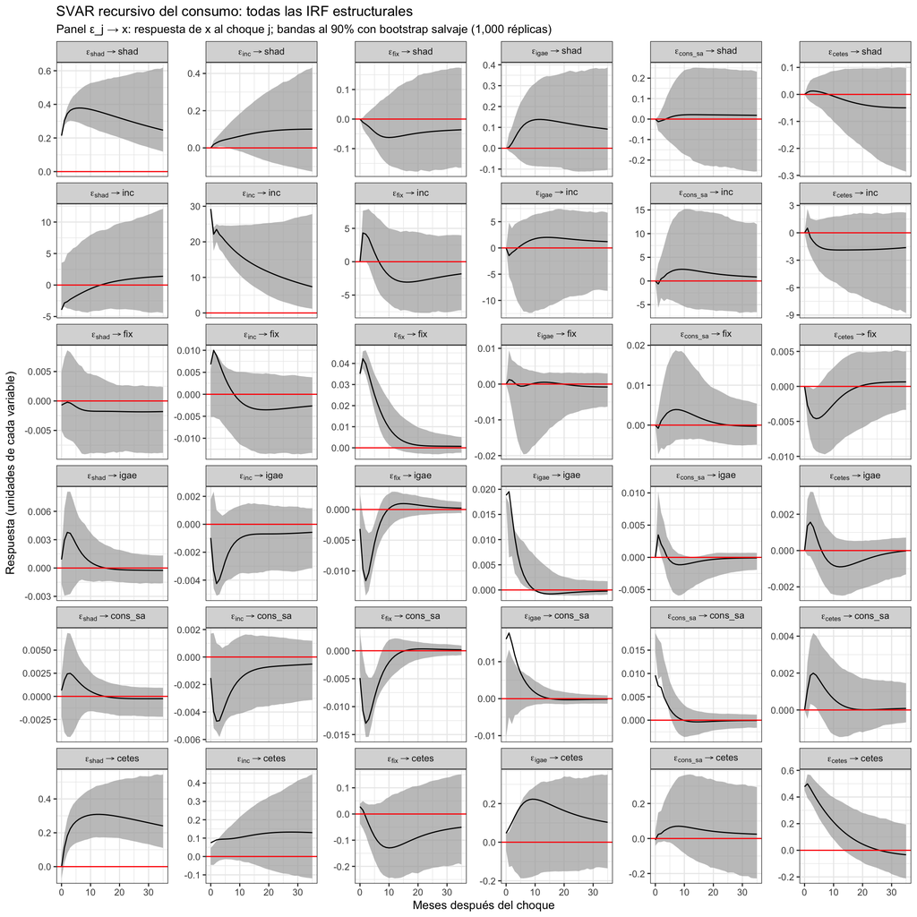

```r
set.seed(2027)
cores <- max(1, parallel::detectCores() - 1)

# CONSUMO:
boot.c.svar <- wild.boot(c.svar, n.ahead = 36, nboot = 1000, nc = cores)
plot(boot.c.svar, lowerq = 0.05, upperq = 0.95) +
  labs(title = "SVAR recursivo del consumo: todas las IRF estructurales",
       subtitle = "Panel ε_j → x: respuesta de x al choque j; bandas al 90% con bootstrap salvaje (1,000 réplicas)",
       x = "Meses después del choque", y = "Respuesta (unidades de cada variable)")
```

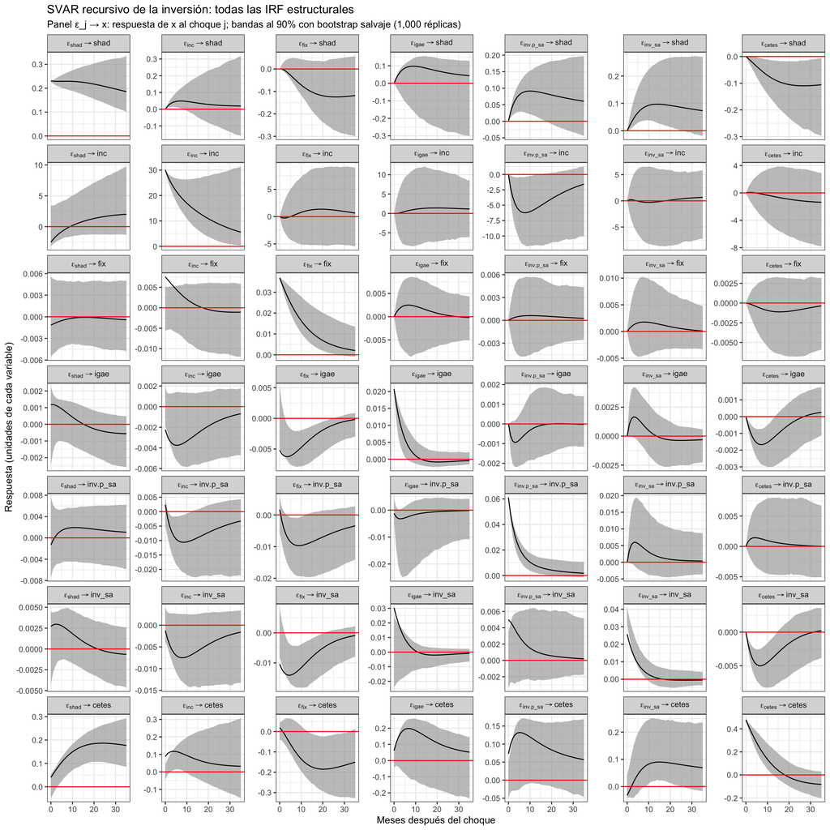

```r
# INVERSIÓN:
boot.i.svar <- wild.boot(i.svar, n.ahead = 36, nboot = 1000, nc = cores)
plot(boot.i.svar, lowerq = 0.05, upperq = 0.95) +
  labs(title = "SVAR recursivo de la inversión: todas las IRF estructurales",
       subtitle = "Panel ε_j → x: respuesta de x al choque j; bandas al 90% con bootstrap salvaje (1,000 réplicas)",
       x = "Meses después del choque", y = "Respuesta (unidades de cada variable)")
```

Cada panel $\varepsilon_j \rightarrow x$ es la respuesta de la variable $x$ (fila) al choque estructural $j$ (columna). Las unidades son las de cada variable: crecimiento anual en logaritmos para `fix`, `igae`, `cons_sa`, `inv_sa` e `inv.p_sa`; puntos porcentuales para `shad` y `cetes`, y puntos del índice para `inc`. Busca la columna del choque `inc` y la fila `cons_sa` o `inv_sa`: es la misma IRF de la Opción A, ahora con bandas al 90% del bootstrap salvaje.

> **¿Y `vars::SVAR()`?** Esa función escribe el modelo como $A u_t = B\varepsilon_t$ y estima por máxima verosimilitud los elementos libres de $A$ o $B$. Sirve para restricciones de corto plazo **no** recursivas (por ejemplo, un cero arriba de la diagonal), pero la optimización es numérica: con variables de escalas tan distintas como `inc` (desviación estándar cercana a 30) e `igae` (cercana a 0.02) no converge a la solución de Cholesky. En el caso recursivo, la solución exacta es $B = \text{chol}(\Sigma_u)$ y no hace falta optimizar nada.

## Ejercicios

1. ¿Qué habría pasado con el ajuste estacional si se declara que las series empiezan en dic-2008 cuando en realidad empiezan en ene-1999? Pruébalo con `seas(ts(data$cons, start = c(2008, 12), frequency = 12))` y compara la lista de atípicos y el regresor de Semana Santa con los de la Sección 3.
2. Cambia el orden del VAR de inversión para que `inv_sa` vaya **antes** que `inv.p_sa`. ¿Cambian la respuesta de `inv_sa` al choque de `inc` y la de `inv.p_sa` al choque de `inv_sa`? Explica qué supuesto económico implica cada orden y por qué la respuesta a `inc` casi no se mueve (pista: piensa en qué columnas de $B$ cambian al permutar sólo las variables 5 y 6).
3. Vuelve a estimar el VAR del consumo con $p = 3$ (lo que sugiere el AIC) y, por separado, con `inc` en logaritmos. ¿Desaparece la autocorrelación de la prueba Portmanteau? ¿Cambian el signo, la magnitud o la persistencia de la respuesta del consumo?